# A Machine Learning Algorithim for Predicting Human Activity

Davin O’Regan

8/12/2021

## Introduction

This brief note describes the training of a machine learning model to predict human activity from the [human activity recognition data (HAR) initiative](http://web.archive.org/web/20161224072740/http:/groupware.les.inf.puc-rio.br/har). The model employed a random forest analytic technique using training data obtained from the HAR website. Random Forest was chosen due to its higher predictive accuracy after cross-validated comparisons against other modeling techniques. Prior to model fitting, the initial training data set was split into separate training and test sets. Additionally, a separate set of 20 test cases was predicted. I discuss each of my model preparation and execution steps in turn.

## Data Preparation and Pre-Processing

First, I inspected the raw training data using cross tabs and histogram plots and found that large numbers of variables contained entirely empty or nonsensical observations. The missing observations were so extensive that imputation would be verge on data fabrication. These “NA”, empty, or otherwise uninterpretable observations were dropped from the training set. This reduced the number of variables in the data from 160 to 60.

```r
#  Data frame prep for test set
training2 <- training %>%  # Convert empty strings to NAs for exclusion
  mutate_all(na_if, "#DIV/0!") %>%
  mutate_all(na_if, "")
training3 <- training2[,colSums(is.na(training2))==0] # Exclude NAs
training$classe <- as.factor(training$classe)  # Change DV from character to a factor variable
```

```r
# Partition training set to analyze, test
inTrain = createDataPartition(training$classe, p = 3/4)[[1]]
training4 = training3[ inTrain,]
testing = training3[-inTrain,]
```

## Model Selection and training

Next, I trained a model using all available data in the training set and three different modeling techniques: linear discriminant analysis, gradient boosting, and random forest. Each model was run using 10-fold repeated cross validation.

```r
library(parallel)
library(doParallel)
cluster <- parallel::makeCluster(2, setup_strategy = "sequential") # convention to leave 1 core for OS
  # Set parallel processing parameters based on this: https://stackoverflow.com/questions/62730783/error-in-makepsockclusternames-spec-cluster-setup-failed-3-of-3-work
  # And this https://github.com/lgreski/datasciencectacontent/blob/master/markdown/pml-randomForestPerformance.md
registerDoParallel(cluster) # Commence parallel processing
ctrl <- trainControl(method="repeatedcv", number=10, allowParallel = T) # Set cross validation parameters

set.seed(1980)
# Train RF model
mrf <- train(classe~ ., method="rf", data=training4[,8:60], trControl=ctrl)

# Train GBM model
mgbm <- train(classe~ ., method="gbm", data=training4[,8:60], trControl=ctrl)
# Train an LDA model
mlda <- train(classe~., method="lda", data=training4[,8:60])
```

I then compared the out-of-sample performance of each of these models on the testing data. The random forest model had the highest predictive accuracy, as demonstrated in the below figure.

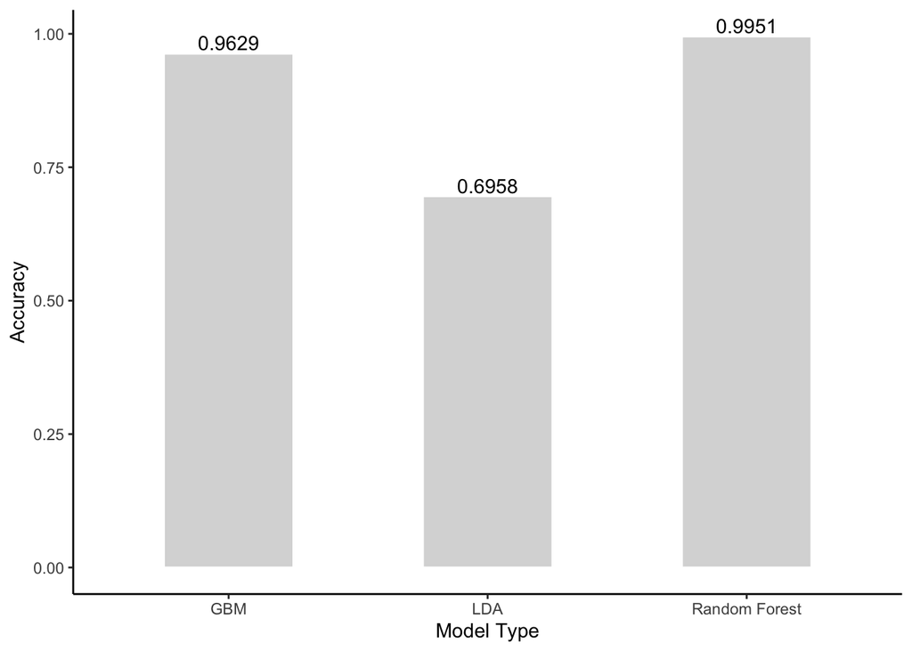

```r
# Validate on Test Set
phat_rf <- predict(mrf, testing[,8:60])
phat_lda <- predict(mlda, testing[,8:60])
phat_gbm <- predict(mgbm, testing[,8:60])

rf_accuracy <- sum(phat_rf == testing$classe) /  length(testing$classe)
lda_accuracy <- sum(phat_lda == testing$classe) /  length(testing$classe)
gbm_accuracy <- sum(phat_gbm == testing$classe) /  length(testing$classe)

acy <- data.frame(accuracy=c(rf_accuracy,lda_accuracy,gbm_accuracy),
                  model_type = c("Random Forest", "LDA", "GBM"))
# Plot of accuracy levels
a <- ggplot(acy,aes(x=model_type, y=accuracy)) +
  geom_bar(stat="identity", fill="grey", alpha=.6, color="white", width=.5) +
  geom_text(aes(label=paste(round(accuracy, 4))),
            position=position_dodge(width=0.9), vjust=-0.25) +
  ylab("Accuracy") +
  xlab("Model Type") +
  theme_classic()
a
```

| ID | Predicted Activity |
| --- | --- |
| 1 | B |
| 2 | A |
| 3 | B |
| 4 | A |
| 5 | A |
| 6 | E |
| 7 | D |
| 8 | B |
| 9 | A |
| 10 | A |
| 11 | B |
| 12 | C |
| 13 | B |
| 14 | A |
| 15 | E |
| 16 | E |
| 17 | A |
| 18 | B |
| 19 | B |
| 20 | B |